# Lab 1: Gapminder Data Visualization

Author

Lily

**GitHub Repository**: https://github.com/lilysteinberg/GSB-544---Computing-and-ML/tree/main/Week%201

# Task 1

1. The aesthetics are x = income, y = life expectancy, size = population, color = four_regions, and fill = four_regions.

```python
# load packages
import pandas as pd
from plotnine import *
from matplotlib import colors as mcolors

# load data
dfQ1 = pd.read_csv('q1data.csv')
dfQ1 = dfQ1.dropna()
```

::: {#cell-Task 1 plot 1 .cell execution_count=2}

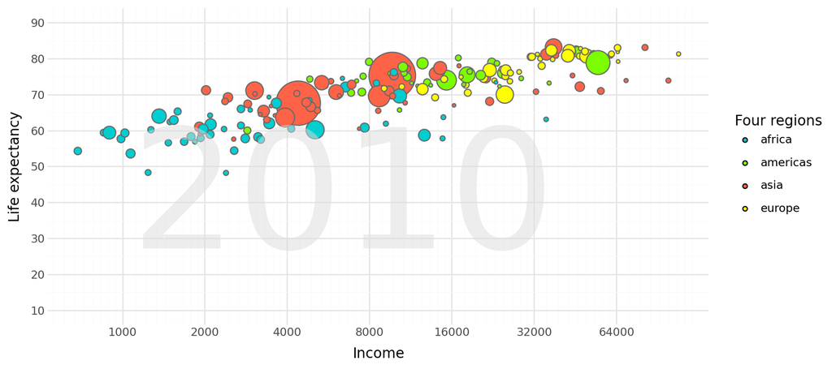

```python
# setting up custom colors based on matplotlib library options
custom_colors = {
    'africa': 'darkturquoise',
    'americas': 'lawngreen',
    'asia': 'tomato',
    'europe': 'yellow'
    }

custom_outline = {
    'africa': 'dimgray',
    'americas': 'dimgray',
    'asia': 'dimgray',
    'europe': 'dimgray'
    }

# plot
(ggplot(dfQ1,
aes(
    x = "income",
    y = "life_exp",
    size = "population",
    color = "four_regions",
    fill = "four_regions"
))
# bubbles
+ geom_point ()
+ scale_color_manual(values = custom_outline)
+ scale_fill_manual(values = custom_colors)
+ scale_size_continuous(range=(1, 20))
# axes and legends
+ scale_x_log10(breaks = [500, 1000, 2000, 4000, 8000, 16000, 32000, 64000])
+ scale_y_continuous(limits=(10,90), breaks = range(10,91,10))
+ labs(x= "Income", y = "Life expectancy", fill = "Four regions")
+ guides(size = "none", color = "none")
# background
+ theme_minimal()
# 2010 watermark
+ annotate("text", x=6400, y=40, label="2010", size=130, color = "gainsboro", alpha=0.5, ha="center", va="center")
# set size
+theme(figure_size=(9, 4))
)
```

:::

4. A box plot could be used to compare income and life expectancy across the four regions. This could be helpful to draw more generalized, regional comparisons, however it lacks detail at the individual country level.

::: {#cell-Task 1 plot 2 .cell execution_count=3}

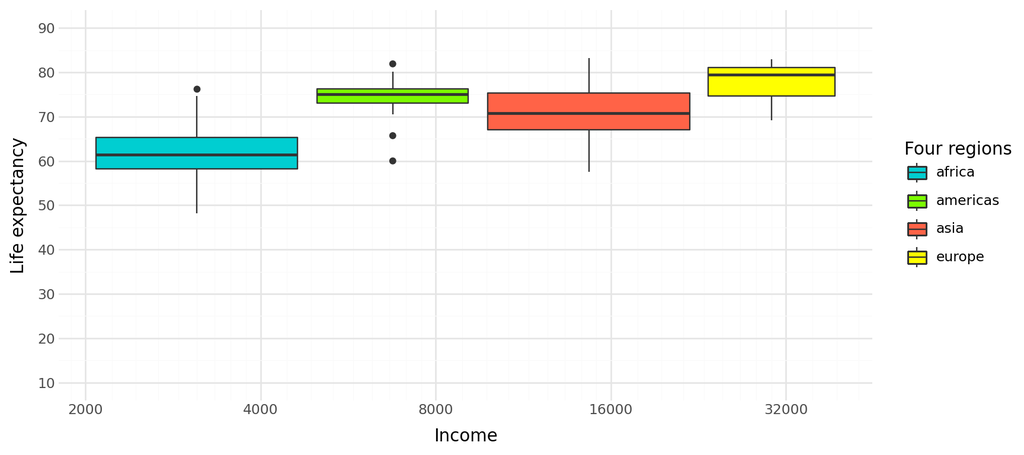

```python
(ggplot(dfQ1,
aes(
    x = "income",
    y = "life_exp",
    fill = "four_regions"
))
# boxes
+ geom_boxplot()
+ scale_fill_manual(values=custom_colors)
# axes and legends
+ scale_x_log10(breaks = [500, 1000, 2000, 4000, 8000, 16000, 32000, 64000])
+ scale_y_continuous(limits=(10,90), breaks = range(10,91,10))
+ labs(x= "Income", y = "Life expectancy", fill = "Four regions")
# background
+ theme_minimal()
# set size
+theme(figure_size=(9, 4))
)
```

:::

# Task 2

1. The aesthetics are x = exports, y = imports, size = energy, color = four_regions, and fill = four_regions.

```python
# load data
dfQ2 = pd.read_csv('q2data.csv')

# variable corrections
#    define function
def float_k(x):
    if type(x) == str and 'k' in x.lower():
        return float(x.replace('k', ''))*1000
    elif type(x) == float:
        return 0
    return float(x)

#    apply function
dfQ2['energy'] = dfQ2['energy'].apply(float_k)

# remove NaN from regions
dfQ2 = dfQ2.dropna(axis=0, subset=['four_regions'])
```

::: {#cell-Task 2 plot 1 .cell execution_count=5}

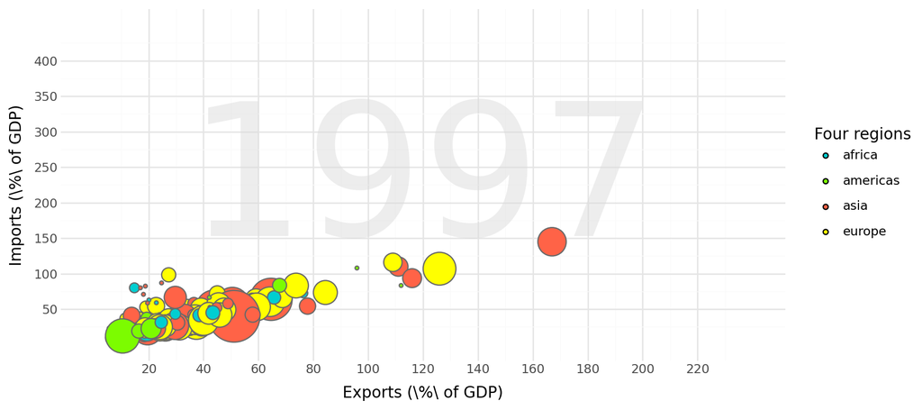

```python
(ggplot(dfQ2,
aes(
    x = "exports",
    y = "imports",
    size = "energy",
    color = "four_regions",
    fill = "four_regions"
))
# bubbles
+ geom_point()
+ scale_color_manual(values = custom_outline)
+ scale_fill_manual(values = custom_colors)
+ scale_size_continuous(range=(1,20))
# axes and legends
+ scale_x_continuous(limits=(0,240), breaks = list(range(20,221,20)))
+ scale_y_continuous(limits=(0,450), breaks = list(range(50,401,50)))
+ labs(x= "Exports (\%\ of GDP)", y = "Imports (\%\ of GDP)", fill = "Four regions")
+ guides(size = "none", color = "none")
# background
+ theme_minimal()
# 1997 watermark
+ annotate("text", x=120, y=225, label="1997", size=130, color = "gainsboro", alpha=0.5, ha="center", va="center")
# set size
+theme(figure_size=(9, 4))
)
```

:::

4. A bar chart could be used to show the imports and exports across the four regions. To get imports and exports in the same graph, the dataframe would have to be significantly adjusted from how it is now, so I made two separate graphs this time. Like in task 1, this graph could be helpful to show more generalized, regional comparisons, however it lacks detail at the individual country level.

::: {#cell-Task 2 plot 2 .cell execution_count=6}

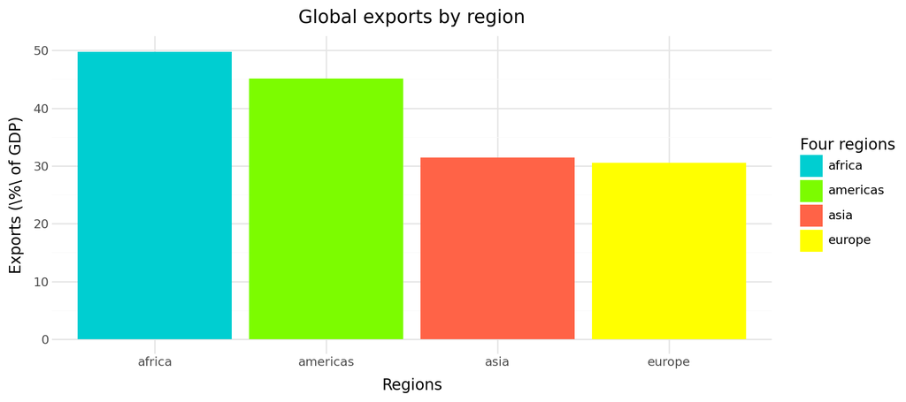

```python
# bar chart - exports
(ggplot(dfQ2,
aes(
    x = "four_regions",
    y = "exports",
    fill = "four_regions"
))
# bars
+ geom_col()
+ scale_fill_manual(values = ['darkturquoise', 'lawngreen', 'tomato', 'yellow'])
# axes and legends
+ scale_y_continuous(limits=(0,50))
+ labs(title = 'Global exports by region', x= "Regions", y = "Exports (\%\ of GDP)", fill = "Four regions")
# background
+ theme_minimal()
# set size
+theme(figure_size=(9, 4))
)
```

:::

::: {#cell-Task 2 plot 3 .cell execution_count=7}

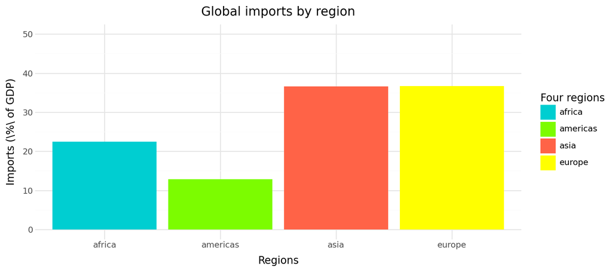

```python
# bar chart - imports
(ggplot(dfQ2,
aes(
    x = "four_regions",
    y = "imports",
    fill = "four_regions"
))
# bars
+ geom_col()
+ scale_fill_manual(values = ['darkturquoise', 'lawngreen', 'tomato', 'yellow'])
# axes and legends
+ scale_y_continuous(limits=(0,50))
+ labs(title = 'Global imports by region', x= "Regions", y = "Imports (\%\ of GDP)", fill = "Four regions")
# background
+ theme_minimal()
# set size
+theme(figure_size=(9, 4))
)
```

:::

# Task 3

1. The aesthetics are x = Individuals using the internet, y = GDP/capita, size = income, color = four_regions, and fill = four_regions.

```python
# load data
dfQ3 = pd.read_csv('q3data.csv')

# remove NaN from regions
dfQ3 = dfQ3.dropna(axis=0, subset=['four_regions'])
```

::: {#cell-Task 3 plot 1 .cell execution_count=9}

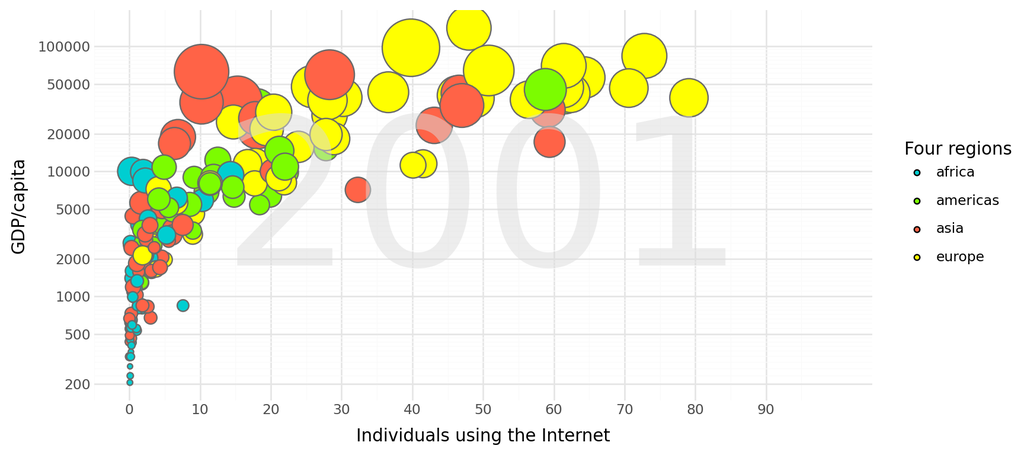

```python
(ggplot(dfQ3,
aes(
    x = "internet_users",
    y = "gdp",
    size = "income",
    color = "four_regions",
    fill = "four_regions"
))
# bubbles
+ geom_point()
+ scale_color_manual(values = custom_outline)
+ scale_fill_manual(values = custom_colors)
+ scale_size_continuous(range=(1,20))
# axes and legends
+ scale_x_continuous(limits=(0,100), breaks = list(range(0,91,10)))
+ scale_y_log10(breaks = [200, 500, 1000, 2000, 5000, 10000, 20000, 50000, 100000])
+ labs(x= "Individuals using the Internet", y = "GDP/capita", fill = "Four regions")
+ guides(size = "none", color = "none")
# background
+ theme_minimal()
# 2001 watermark
+ annotate("text", x=50, y=5000, label="2001", size=130, color = "gainsboro", alpha=0.5, ha="center", va="center")
# set size
+theme(figure_size=(9, 4))
)
```

:::

4. A density chart could be used to show the levels of GDP and internet users across the four regions. Again, this graph could be helpful to show more generalized, regional comparisons, however it lacks detail at the individual country level and the ability to convey multiple continuous variables simultaneously, like the bubble chart can.

::: {#cell-Task 3 plot 2 .cell execution_count=10}

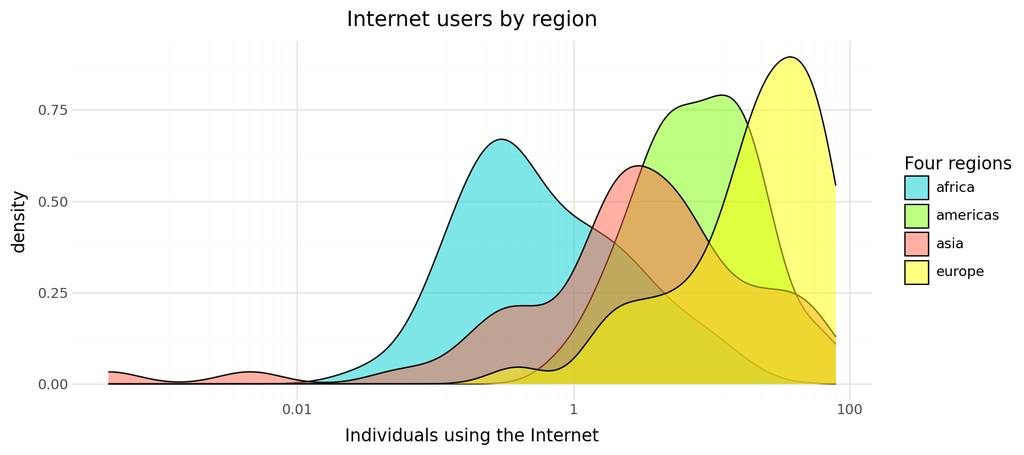

```python
(ggplot(dfQ3,
aes(
    x = "internet_users",
    fill = "four_regions"
))
# density
+ geom_density(alpha = 0.5)
+ scale_fill_manual(values = custom_colors)
# axes and legends
+ scale_x_log10()
+ labs(title = "Internet users by region", x= "Individuals using the Internet", fill = "Four regions")
# background
+ theme_minimal()
# set size
+theme(figure_size=(9, 4))
)
```

:::

::: {#cell-Task 3 plot 3 .cell execution_count=11}

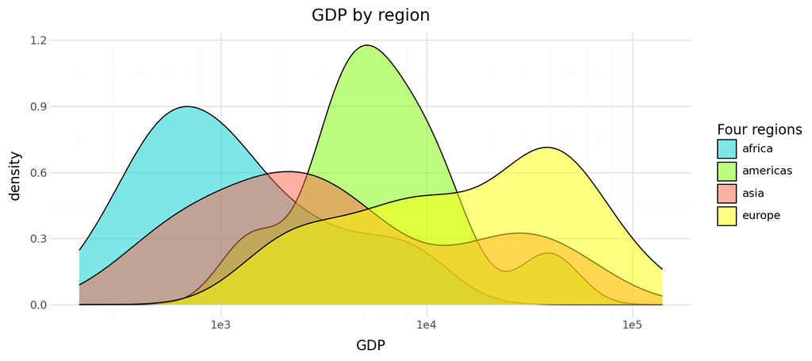

```python
(ggplot(dfQ3,
aes(
    x = "gdp",
    fill = "four_regions"
))
# density
+ geom_density(alpha = 0.5)
+ scale_fill_manual(values = custom_colors)
# axes and legends
+ scale_x_log10()
+ labs(title = "GDP by region", x= "GDP", fill = "Four regions")
# background
+ theme_minimal()
# set size
+theme(figure_size=(9, 4))
)
```

:::